# Chap3.1-3.3

Mijeong Kim

```r
library(tsibble)
library(tsibbledata)
library(tibble)
library(dplyr)
library(knitr)
library(ggplot2)
library(fpp3)
```

## 3.1 Transformations and adjustments

```r
#### Population adjustments
global_economy
```

```
## # A tsibble: 15,150 x 9 [1Y]
## # Key:       Country [263]
##    Country     Code   Year         GDP Growth   CPI Imports Exports Population
##    <fct>       <fct> <dbl>       <dbl>  <dbl> <dbl>   <dbl>   <dbl>      <dbl>
##  1 Afghanistan AFG    1960  537777811.     NA    NA    7.02    4.13    8996351
##  2 Afghanistan AFG    1961  548888896.     NA    NA    8.10    4.45    9166764
##  3 Afghanistan AFG    1962  546666678.     NA    NA    9.35    4.88    9345868
##  4 Afghanistan AFG    1963  751111191.     NA    NA   16.9     9.17    9533954
##  5 Afghanistan AFG    1964  800000044.     NA    NA   18.1     8.89    9731361
##  6 Afghanistan AFG    1965 1006666638.     NA    NA   21.4    11.3     9938414
##  7 Afghanistan AFG    1966 1399999967.     NA    NA   18.6     8.57   10152331
##  8 Afghanistan AFG    1967 1673333418.     NA    NA   14.2     6.77   10372630
##  9 Afghanistan AFG    1968 1373333367.     NA    NA   15.2     8.90   10604346
## 10 Afghanistan AFG    1969 1408888922.     NA    NA   15.0    10.1    10854428
## # ℹ 15,140 more rows
```

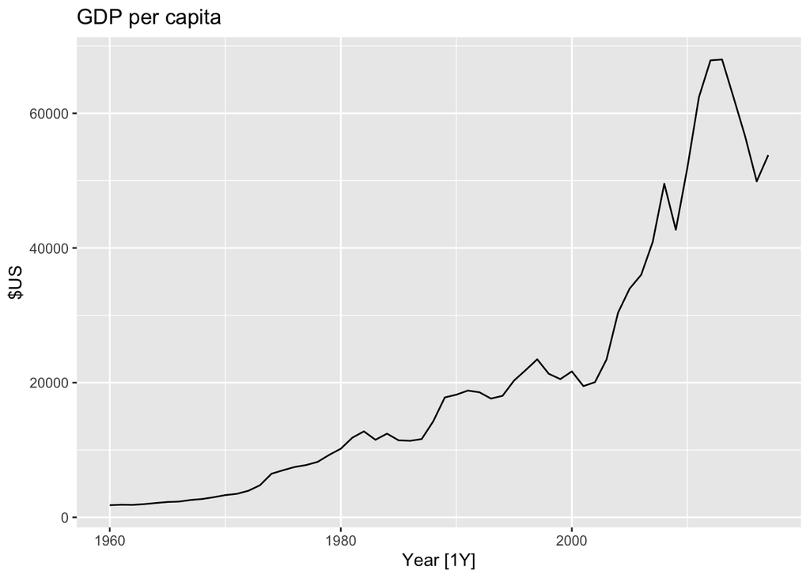

```r
global_economy |>
  filter(Country == "Australia") |>
  autoplot(GDP/Population) +
  labs(title= "GDP per capita", y = "$US")
```

```r
#### Inflation adjustments
head(aus_retail)
```

```
## # A tsibble: 6 x 5 [1M]
## # Key:       State, Industry [1]
##   State                        Industry            `Series ID`    Month Turnover
##   <chr>                        <chr>               <chr>          <mth>    <dbl>
## 1 Australian Capital Territory Cafes, restaurants… A3349849A   1982 Apr      4.4
## 2 Australian Capital Territory Cafes, restaurants… A3349849A   1982 May      3.4
## 3 Australian Capital Territory Cafes, restaurants… A3349849A   1982 Jun      3.6
## 4 Australian Capital Territory Cafes, restaurants… A3349849A   1982 Jul      4
## 5 Australian Capital Territory Cafes, restaurants… A3349849A   1982 Aug      3.6
## 6 Australian Capital Territory Cafes, restaurants… A3349849A   1982 Sep      4.2
```

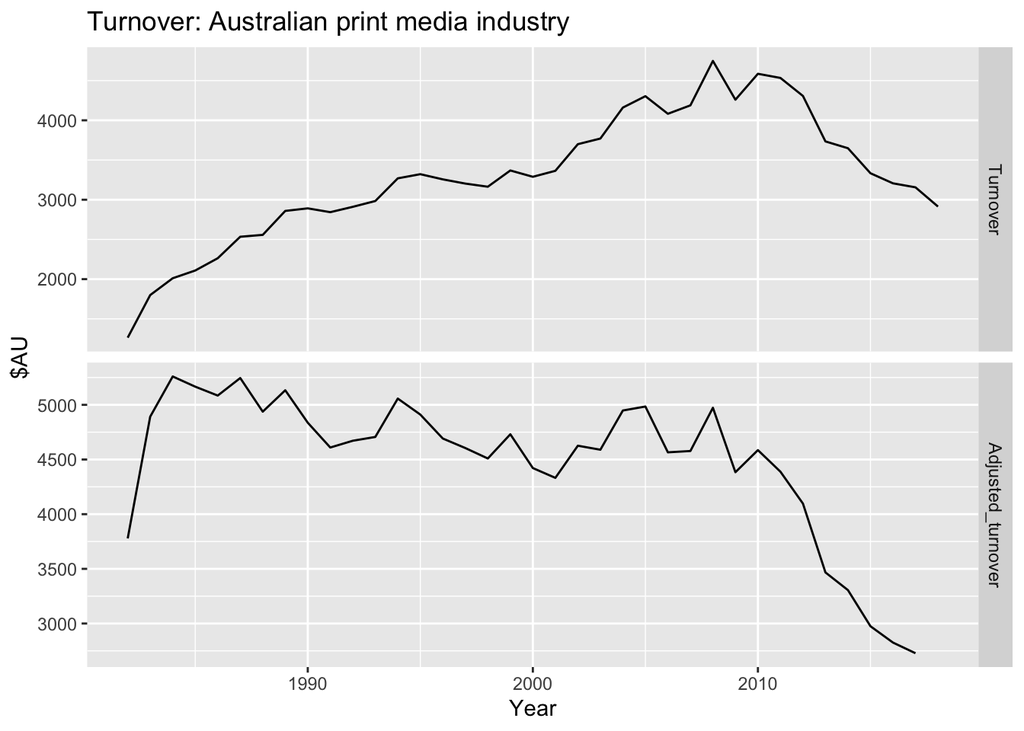

```r
print_retail <- aus_retail |>
  filter(Industry == "Newspaper and book retailing") |>
  group_by(Industry) |>
  index_by(Year = year(Month)) |>
  summarise(Turnover = sum(Turnover))

aus_economy <- global_economy |>
  filter(Code == "AUS")

print_retail |>
  left_join(aus_economy, by = "Year") |>
  mutate(Adjusted_turnover = Turnover / CPI * 100) |>
  pivot_longer(c(Turnover, Adjusted_turnover),
               values_to = "Turnover") |>
  mutate(name = factor(name,
                       levels=c("Turnover","Adjusted_turnover"))) |>
  ggplot(aes(x = Year, y = Turnover)) +
  geom_line() +
  facet_grid(name ~ ., scales = "free_y") +
  labs(title = "Turnover: Australian print media industry",
       y = "$AU")
```

### 명목 매출과 실질 매출 비교

먼저 `print_retail` 데이터에 호주의 경제지표(`aus_economy`)를 결합한 후,  
소매 매출을 물가(CPI)로 조정하여 **실질 매출(real turnover)**을 계산한다.

pivot_longer는 데이터를 wide format(가로형)에서 long format(세로형)으로 변환하는 함수

pivot_longer(data, cols, names_to, values_to)

- cols: 길게 만들 열
- names_to: 열 이름이 들어갈 변수
- values_to: 값이 들어갈 변수

이 경우에는 pivot_longer(c(Turnover, Adjusted_turnover), values_to = “Turnover”)

Turnover, Adjusted_turnover 두 열을 세로로 합쳐서 하나의 열 Turnover로 만든다.

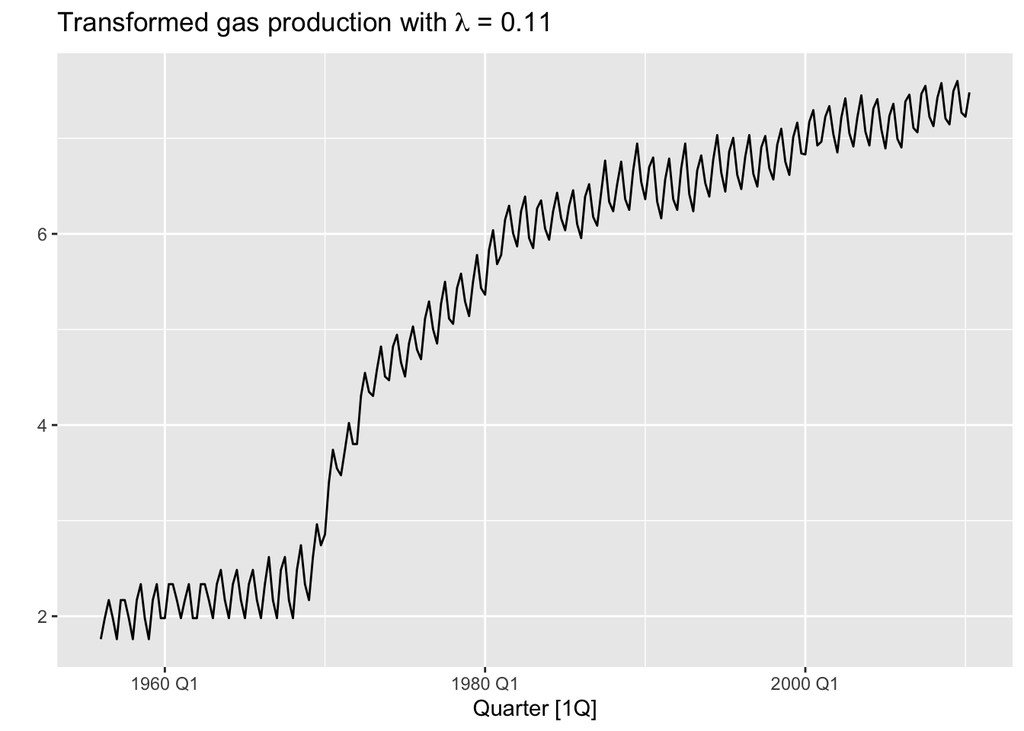

```r
####### Box-Cox transformation #####

lambda <- aus_production |>
  features(Gas, features = guerrero) |>
  pull(lambda_guerrero)
aus_production |>
  autoplot(box_cox(Gas, lambda)) +
  labs(y = "",
       title = latex2exp::TeX(paste0(
         "Transformed gas production with $\\lambda$ = ",
         round(lambda,2))))
```

### Box–Cox 변환

로그 변환과 거듭제곱(power) 변환을 모두 포함하는 유용한 변환 방법으로  
**Box–Cox 변환(Box & Cox, 1964)**이 있다. 이 변환은 매개변수 $\lambda$에 의존하며 다음과 같이 정의된다.

$$w_t =
\begin{cases}
\log(y_t), & \text{if } \lambda = 0 \\
\dfrac{\text{sign}(y_t)|y_t|^{\lambda} - 1}{\lambda}, &
\text{otherwise}
\end{cases}$$

이 식은 **Bickel & Doksum (1981)**에서 제안된 **수정된 Box–Cox 변환(modified Box–Cox transformation)**이다.  
이 변환은 $\lambda > 0$인 경우 $y_t$가 음수 값을 가져도 적용할 수 있도록 확장된 형태이다.

Box–Cox 변환에서 사용되는 로그는 항상 **자연로그(natural logarithm)**, 즉 밑이 $e$인 로그이다.  
따라서

- $\lambda = 0$이면 **자연로그 변환(log transformation)**이 사용되고,
- $\lambda \neq 0$이면 **거듭제곱 변환(power transformation)**이 적용된 후 간단한 스케일 조정이 이루어진다.

특히 $\lambda = 1$인 경우

$$w_t = y_t - 1$$

이 되므로 데이터가 단순히 **아래로 평행 이동**될 뿐 시계열의 **형태(shape)는 변하지 않는다.**

반면 $\lambda \neq 1$인 경우에는 시계열의 **분포와 형태가 변화**하게 된다.

## 3.2 Time series components

### 가법적 (additive) 분해

$$y_t = S_t + T_t + R_t$$

- $S_t$: 계절 (seasonal) 성분
- $T_t$: 추세-순환 (trend-cycle) 성분
- $R_t$: 잔차 (remainder) 성분

계절 변동의 크기나 추세-순환 성분 주위의 변동이 **시계열의 수준과 관계없이 일정할 때 적절**하다.

### 승법적 (multiplicative) 분해

$$y_t = S_t \times T_t \times R_t$$

로그 변환을 적용하면:

$$\log y_t = \log S_t + \log T_t + \log R_t$$

계절 패턴이나 추세-순환 성분 주위의 변동이 **시계열의 수준에 비례하여 변화할 때 더 적절**하다.  
**경제 데이터에서는 승법적 분해가 일반적**이다.

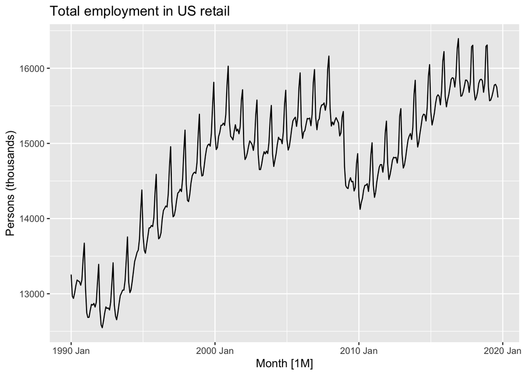

```r
## Employment in the US retail sector
us_retail_employment <- us_employment |>
  filter(year(Month) >= 1990, Title == "Retail Trade") |>
  select(-Series_ID)
autoplot(us_retail_employment, Employed) +
  labs(y = "Persons (thousands)",
       title = "Total employment in US retail")
```

```r
dcmp <- us_retail_employment |>
  model(stl = STL(Employed))
components(dcmp)
```

```
## # A dable: 357 x 7 [1M]
## # Key:     .model [1]
## # :        Employed = trend + season_year + remainder
##    .model    Month Employed  trend season_year remainder season_adjust
##    <chr>     <mth>    <dbl>  <dbl>       <dbl>     <dbl>         <dbl>
##  1 stl    1990 Jan   13256. 13288.      -33.0      0.836        13289.
##  2 stl    1990 Feb   12966. 13269.     -258.     -44.6          13224.
##  3 stl    1990 Mar   12938. 13250.     -290.     -22.1          13228.
##  4 stl    1990 Apr   13012. 13231.     -220.       1.05         13232.
##  5 stl    1990 May   13108. 13211.     -114.      11.3          13223.
##  6 stl    1990 Jun   13183. 13192.      -24.3     15.5          13207.
##  7 stl    1990 Jul   13170. 13172.      -23.2     21.6          13193.
##  8 stl    1990 Aug   13160. 13151.       -9.52    17.8          13169.
##  9 stl    1990 Sep   13113. 13131.      -39.5     22.0          13153.
## 10 stl    1990 Oct   13185. 13110.       61.6     13.2          13124.
## # ℹ 347 more rows
```

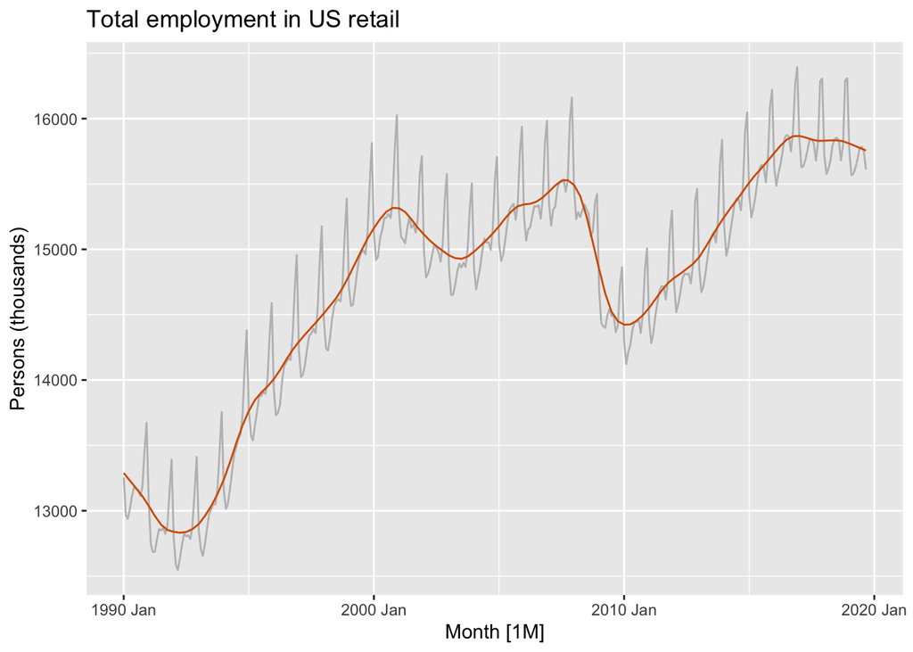

```r
components(dcmp) |>
  as_tsibble() |>
  autoplot(Employed, colour="gray") +
  geom_line(aes(y=trend), colour = "#D55E00") +
  labs(
    y = "Persons (thousands)",
    title = "Total employment in US retail"
  )
```

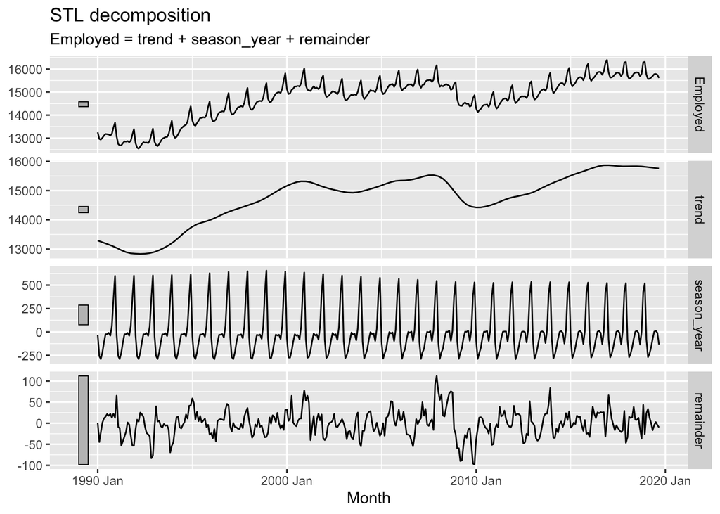

```r
components(dcmp) |> autoplot()
```

- 세 가지 구성 요소(계절, 추세-순환, 잔차)가 개별적으로 표시되며, 이를 합치면 원래 데이터를 재구성할 수 있음.
- 계절 성분은 시간이 지나면서 변화하며, 연속된 해는 유사하지만 멀리 떨어진 연도는 다른 패턴을 가질 수 있음.
- 잔차 성분은 계절 및 추세-순환 성분을 제거한 후 남은 부분을 의미함.
- 각 패널의 왼쪽 회색 막대는 상대적인 크기를 나타내며, 잔차 성분의 막대가 가장 크면 변동성이 가장 작음을 의미함.
- 모든 패널을 동일한 스케일로 조정하면 데이터 변동성을 직접 비교할 수 있음.

### Seasonally adjusted data

- 계절 성분을 제거한 데이터를 **계절 조정된 데이터(seasonally adjusted data)**라고 함.
- 가법적 분해에서는 $y_t-S_t$, 승법적 분해에서는 $y_t/S_t$로 계산됨.
- 그림 3.8은 계절 조정된 소매업 종사자 수를 보여줌.

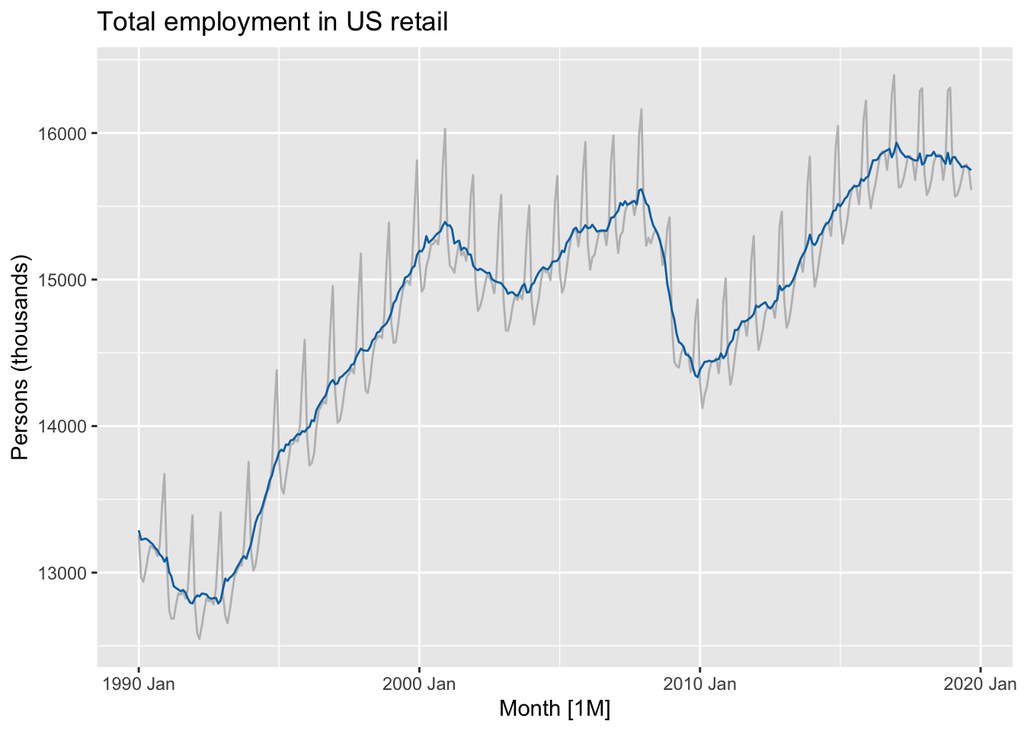

```r
components(dcmp) |>
  as_tsibble() |>
  autoplot(Employed, colour = "gray") +
  geom_line(aes(y=season_adjust), colour = "#0072B2") +
  labs(y = "Persons (thousands)",
       title = "Total employment in US retail")
```

- 계절 변동이 주요 관심사가 아닐 때, 계절 조정된 데이터가 유용함.
- 예를 들어, 월별 실업률 데이터는 계절 변동이 아닌 경제적 요인을 강조하기 위해 조정됨.
- 실업률 증가가 계절적 요인(졸업생 구직)인지, 경제 불황 때문인지 구분하는 데 도움이 됨.
- 계절 조정 데이터에는 잔차(remainder)와 추세-순환(trend-cycle) 성분이 포함되므로 완전히 부드럽지 않음.
- 변곡점(turning points) 분석이나 방향성 해석에는 계절 조정 데이터보다 추세-순환 성분을 활용하는 것이 더 적절함.

## 3.3 Moving averages

- 고전적 시계열 분해는 1920년대에 등장하여 1950년대까지 널리 사용되었으며, 현재 많은 분해 방법의 기초가 됨.
- 첫 단계는 이동 평균(moving average) 방법을 사용하여 추세-순환(trend-cycle)을 추정하는 것.

### 이동 평균 평활법(Moving average smoothing)

차수(order) m인 이동 평균(moving average)

$$\hat{T_t} = \frac{1}{m} \sum_{j=-k}^{k} y_{t+j}$$
이 때, $m=2k+1$.

- 이동 평균을 취하면 무작위 변동을 줄이고 부드러운 추세-순환 성분을 남길 수 있음.
- 그림 3.9는 1960~2017년 호주의 상품 및 서비스 수출이 GDP에서 차지하는 비율을 보여줌 (표 3.1에 데이터 포함).

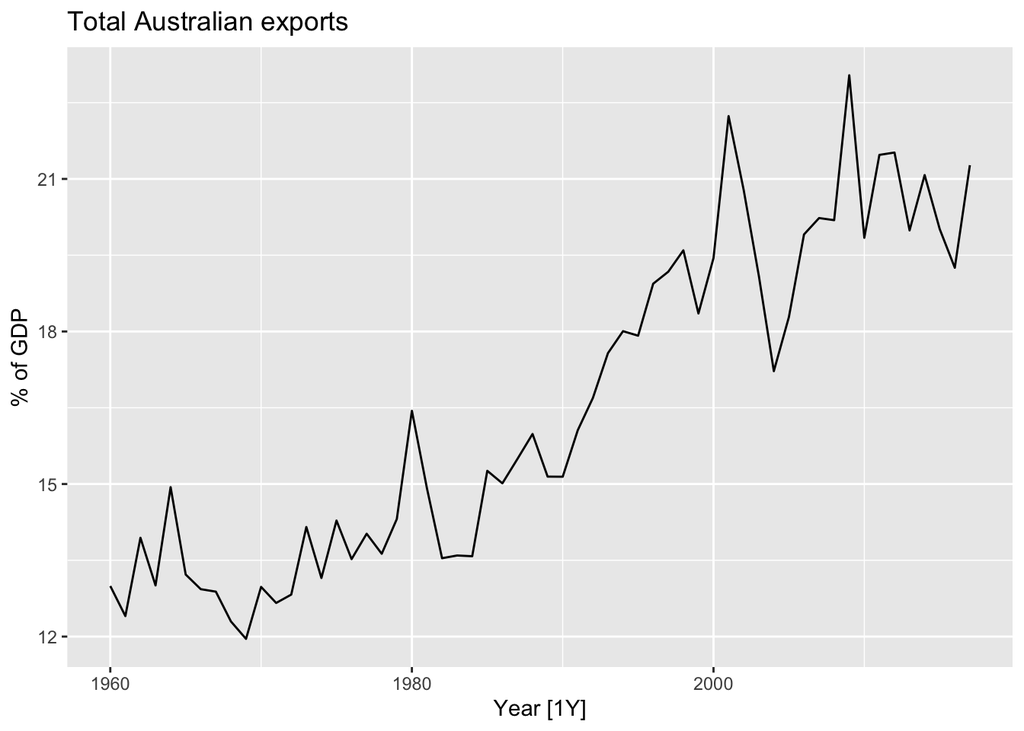

```r
global_economy |>
  filter(Country == "Australia") |>
  autoplot(Exports) +
  labs(y = "% of GDP", title = "Total Australian exports")
```

slider 패키지의 slide_dbl() 함수는 **슬라이딩 윈도우(sliding time window)**를 사용하여 주어진 함수를 적용하는 기능을 제공한다. 이 경우, 5개 기간을 포함하는 창(window)에서 mean() 함수를 사용하여 이동 평균을 계산한다.

```r
aus_exports <- global_economy |>
  filter(Country == "Australia") |>
  mutate(
    `5-MA` = slider::slide_dbl(Exports, mean,
                .before = 2, .after = 2, .complete = TRUE)
  )
aus_exports
```

```
## # A tsibble: 58 x 10 [1Y]
## # Key:       Country [1]
##    Country   Code   Year      GDP Growth   CPI Imports Exports Population `5-MA`
##    <fct>     <fct> <dbl>    <dbl>  <dbl> <dbl>   <dbl>   <dbl>      <dbl>  <dbl>
##  1 Australia AUS    1960  1.86e10  NA     7.96    14.1    13.0   10276477   NA
##  2 Australia AUS    1961  1.96e10   2.49  8.14    15.0    12.4   10483000   NA
##  3 Australia AUS    1962  1.99e10   1.30  8.12    12.6    13.9   10742000   13.5
##  4 Australia AUS    1963  2.15e10   6.21  8.17    13.8    13.0   10950000   13.5
##  5 Australia AUS    1964  2.38e10   6.98  8.40    13.8    14.9   11167000   13.6
##  6 Australia AUS    1965  2.59e10   5.98  8.69    15.3    13.2   11388000   13.4
##  7 Australia AUS    1966  2.73e10   2.38  8.98    15.1    12.9   11651000   13.3
##  8 Australia AUS    1967  3.04e10   6.30  9.29    13.9    12.9   11799000   12.7
##  9 Australia AUS    1968  3.27e10   5.10  9.52    14.5    12.3   12009000   12.6
## 10 Australia AUS    1969  3.66e10   7.04  9.83    13.3    12.0   12263000   12.6
## # ℹ 48 more rows
```

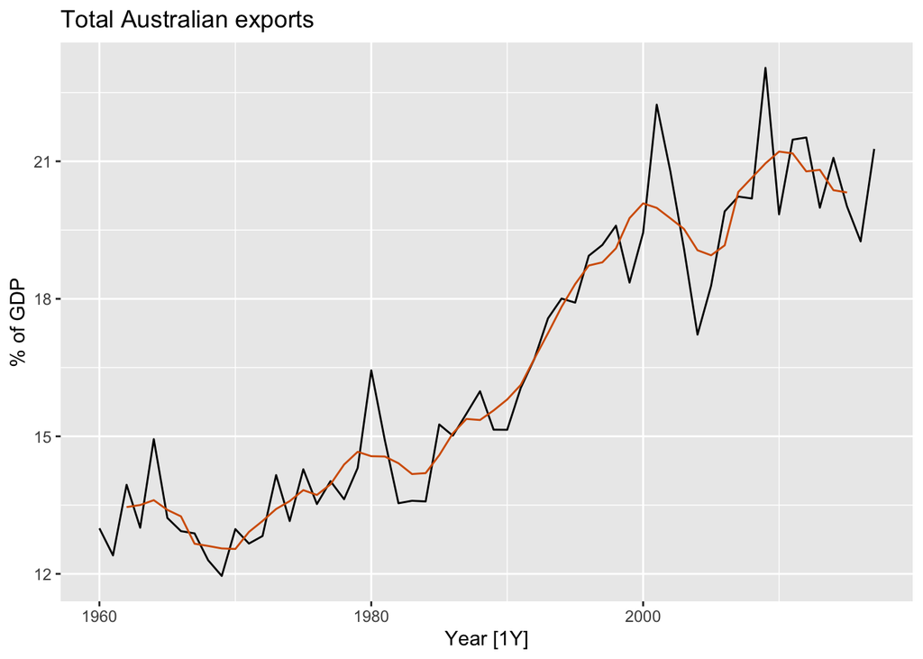

```r
aus_exports |>
  autoplot(Exports) +
  geom_line(aes(y = `5-MA`), colour = "#D55E00") +
  labs(y = "% of GDP",
       title = "Total Australian exports")
```

- 차수가 클수록 더욱 부드러운 곡선이 생성된다.
- 단순 이동 평균은 일반적으로 홀수 차수(예: 3, 5, 7 등)를 사용함. 홀수 차수($m=2k+1$)를 사용하면 대칭적인 이동 평균을 유지할 수 있음.
- 중앙 값과 양쪽 $k$개의 관측값을 평균하여 계산됨.
- 짝수 차수의 경우 대칭성이 깨지므로 일반적으로 사용되지 않음.